# Relación del sedentarismo con problemas auditivos y visuales

2023-12-10

## ÍNDICE

- Introducción
- Objetivos
- Métodos
- Resultados
- Discusión

## INTRODUCCIÓN 📖

El sedentarismo representa un **serio problema** para la salud pública, especialmente en Occidente, según Rodulfo, J. I. A. (2019) 🤓 [1].

Algunos efectos según Hu, F. B. (2003) 🤓 [2]:

• Hipertensión

• Diabetes tipo II

• Obesidad

Ahora bien, ¿alguna vez os habéis planteado **cómo afecta al sedentarismo a otros aspectos acerca de nuestra salud no tan obvios**?

## OBJETIVOS

• Relación entre el sedentarismo y el uso de audífonos por grupos de edad

• Relación entre el sedentarismo y el uso de audífonos según el sexo

• Relación entre el sedentarismo y el uso de gafas por grupos de edad

• Relación entre el sedentarismo y el uso de gafas según el sexo

## MÉTODOS (I)

### Importamos las librerías y los datos a usar

```r
library(tidyjson)
library(rjson)
library(tidyverse)
```

## MÉTODOS (II)

### Importamos las librerías y los datos a usar

```r
library(readr)
library(readxl)
library(dplyr)
library(ggplot2)
library(tidyr)
library(ggborderline)
library(ggdark)


audifono_sexo_edad <- fromJSON(file = "INPUT/DATOS/audif_SexAge_miles.json")
gafas_sexo_edad <- fromJSON(file = "INPUT/DATOS/gafas_SexAge_miles.json")
imc_sexo_edad <- fromJSON(file = "INPUT/DATOS/imc_SexAge_miles.json")
sedentarismo_sexo_edad <- fromJSON(file = "INPUT/DATOS/seden_SexAge_miles.json")
```

## MÉTODOS (III)

### FORMATEO DE DATOS

```r
audif_sexo_edad <- audifono_sexo_edad %>% spread_all()
gafas_sexo_edad <- gafas_sexo_edad %>% spread_all()
imc_sexo_edad <- imc_sexo_edad %>% spread_all()
sedent_sexo_edad <- sedentarismo_sexo_edad %>% spread_all()
```

#### Formateamos el conjunto de datos: “imc_SexAge”

```r
imc_sexo_edad %>% gather_object %>% json_types %>% count(name,type)
```

```
## # A tibble: 3 × 3
##   name     type       n
##   <chr>    <fct>  <int>
## 1 Data     array    162
## 2 MetaData array    162
## 3 Nombre   string   162
```

## MÉTODOS (IV)

#### Formateamos el conjunto de datos: “imc_SexAge”

```r
imc_SexAge <- imc_sexo_edad %>%
enter_object(Data) %>%
gather_array %>%
spread_all()
imc_SexAge$Sexo <- NA
imc_SexAge$Edad <- NA
imc_SexAge$IMC <- NA
for (i in 1:dim(imc_SexAge)[1]){
  r <- unlist(gregexpr(',', imc_SexAge$Nombre[i]))
  primera_coma <- r[1]
  segunda_coma <- r[2]
  imc_SexAge$Sexo[i] <- substring(imc_SexAge$Nombre[i], 0, primera_coma-1)
  edad <- substring(imc_SexAge$Nombre[i], primera_coma+1, segunda_coma-1)
  if (edad != " TOTAL"){
  edad <- substring(imc_SexAge$Nombre[i], primera_coma+4, primera_coma+12)
  }
  imc_SexAge$Edad[i] <- edad
  imc_SexAge$IMC[i] <- substring(imc_SexAge$Nombre[i], segunda_coma+1)
}
```

## MÉTODOS (V)

#### Formateamos el conjunto de datos: “imc_SexAge”

Algunas aclaraciones al respecto:

```r
imc_SexAge %>% gather_object %>% json_types %>% count(name,type)
```

```
## # A tibble: 1 × 3
##   name  type       n
##   <chr> <fct>  <int>
## 1 Valor number   162
```

Este “Code Chunk” nos sirve para saber a qué datos hemos de acceder. En particular, se formateará los datos de la categoría array (excepto MetaData). En el resultado anterior, ya dicho array no se encuentra porque ya lo hemos formateado. Además, las funciones unlist(gregexpr()) devuelve el índice de todas las apariciones de un determinado character en un character de mayor longitud. La función substring() devuelve el sub-character presente en un character de mayor longitud entre ciertos índices pasados como argumento.

## MÉTODOS (VI)

### FORMATEO DE DATOS

#### Formateamos el conjunto de datos: “sedent_sexo_edad”

```r
sedent_sexo_edad %>% gather_object %>% json_types %>% count(name, type)
```

```
## # A tibble: 3 × 3
##   name     type       n
##   <chr>    <fct>  <int>
## 1 Data     array    108
## 2 MetaData array    108
## 3 Nombre   string   108
```

## MÉTODOS (VII)

### FORMATEO DE DATOS

#### Formateamos el conjunto de datos: “sedent_sexo_edad”

```r
sedent_SexAge <- sedent_sexo_edad %>%
enter_object(Data) %>%
gather_array %>%
spread_all()
sedent_SexAge$Sexo <- NA
sedent_SexAge$Edad <- NA
sedent_SexAge$Sedentarismo <- NA
for (i in 1:dim(sedent_SexAge)[1]){
  r <- unlist(gregexpr(',', sedent_SexAge$Nombre[i]))
  primera_coma <- r[1]
  segunda_coma <- r[2]
  sedent_SexAge$Sexo[i] <- substring(sedent_SexAge$Nombre[i], 0, primera_coma-1)
  edad <- substring(sedent_SexAge$Nombre[i], primera_coma+1, segunda_coma-1)
  if (edad != " TOTAL"){
  edad <- substring(sedent_SexAge$Nombre[i], primera_coma+4, primera_coma+12)
  }
  sedent_SexAge$Edad[i] <- edad
  sedent_SexAge$Sedentarismo[i] <- substring(sedent_SexAge$Nombre[i], segunda_coma+1)
}
```

## MÉTODOS (VIII)

### FORMATEO DE DATOS

#### Formateamos el conjunto de datos: “gafas_sexo_edad”

```r
gafas_sexo_edad %>% gather_object %>% json_types %>% count(name,type)
```

```
## # A tibble: 3 × 3
##   name     type       n
##   <chr>    <fct>  <int>
## 1 Data     array    108
## 2 MetaData array    108
## 3 Nombre   string   108
```

## MÉTODOS (IX)

### FORMATEO DE DATOS

#### Formateamos el conjunto de datos: “gafas_sexo_edad”

```r
gafas_SexAge <- gafas_sexo_edad %>%
  enter_object(Data) %>%
  gather_array %>%
  spread_all()
gafas_SexAge$Sexo <- NA
gafas_SexAge$Edad <- NA
gafas_SexAge$Gafas <- NA
for (i in 1:dim(gafas_SexAge)[1]){
  r <- unlist(gregexpr(',', gafas_SexAge$Nombre[i]))
  primera_coma <- r[1]
  segunda_coma <- r[2]
  gafas_SexAge$Sexo[i] <- substring(gafas_SexAge$Nombre[i], 0, primera_coma-1)
  edad <- substring(gafas_SexAge$Nombre[i], primera_coma+1, segunda_coma-1)
  if (edad != " TOTAL"){
  edad <- substring(gafas_SexAge$Nombre[i], primera_coma+4, primera_coma+12)
  }
  gafas_SexAge$Edad[i] <- edad
  gafas_SexAge$Gafas[i] <- substring(gafas_SexAge$Nombre[i], segunda_coma+1)
}
```

## MÉTODOS (X)

### FORMATEO DE DATOS

#### Formateamos el conjunto de datos: “audif_sexo_edad”

```r
audif_sexo_edad %>% gather_object %>% json_types %>% count(name, type)
```

```
## # A tibble: 3 × 3
##   name     type       n
##   <chr>    <fct>  <int>
## 1 Data     array    108
## 2 MetaData array    108
## 3 Nombre   string   108
```

## MÉTODOS (XI)

### FORMATEO DE DATOS

#### Formateamos el conjunto de datos: “audif_sexo_edad”

```r
audif_SexAge <- audif_sexo_edad %>%
  enter_object(Data) %>%
  gather_array %>%
  spread_all()
audif_SexAge$Sexo <- NA
audif_SexAge$Edad <- NA
audif_SexAge$Audifono <- NA
for (i in 1:dim(audif_SexAge)[1]){
  r <- unlist(gregexpr(',', audif_SexAge$Nombre[i]))
  primera_coma <- r[1]
  segunda_coma <- r[2]
  audif_SexAge$Sexo[i] <- substring(audif_SexAge$Nombre[i], 0, primera_coma-1)
  edad <- substring(audif_SexAge$Nombre[i], primera_coma+1, segunda_coma-1)
  if (edad != " TOTAL"){
  edad <- substring(audif_SexAge$Nombre[i], primera_coma+4, primera_coma+12)
  }
  audif_SexAge$Edad[i] <- edad
  audif_SexAge$Audifono[i] <- substring(audif_SexAge$Nombre[i], segunda_coma+1)
}
```

## MÉTODOS (XII)

#### *Unión de los conjuntos de datos sedentarismo y uso de audífonos por edad y sexo*

```r
sedent_audif <-
  audif_SexAge %>%
  mutate(numero_audifonos = Valor*1000) %>%
  select("Sexo", "Audifono", "numero_audifonos", "Edad") %>%
  full_join(x = .,
            y = sedent_SexAge %>%
            mutate(personas_sedentarias = Valor*1000) %>%
            select("Sexo", "Sedentarismo", "personas_sedentarias", "Edad"),
            by = c("Sexo" = "Sexo", "Edad" = "Edad"))
```

## MÉTODOS (XIII)

#### *Modificación del conjunto de datos en relación al sedentarismo y al uso de audífonos*

```r
grafico1 <-sedent_audif %>% filter(Sexo != "Ambos sexos") %>%
  filter(Audifono %in% c(" Sí", " No")) %>%
  filter(Sedentarismo %in% c(" Sí", " No")) %>%
  mutate(ratio_audifonos_por_persona = 100*numero_audifonos/personas_sedentarias) %>%
  filter(Edad != " TOTAL")
```

## MÉTODOS (XIV)

#### *Modificación del conjunto de datos en relación al sedentarismo y al uso de audífonos*

```r
cont <- 1
sedentarios <- c(NA, NA, NA, NA, NA, NA, NA, NA)
no_sedentarios <- c(NA, NA, NA, NA, NA, NA, NA, NA)
aux <- 1
  for (i in 1:(length(grafico1$personas_sedentarias)/4)){
  si_sedent <- grafico1$personas_sedentarias[cont]
  cont <- cont + 1
  no_sedent <- grafico1$personas_sedentarias[cont]
  cont <- cont + 3
  sedentarios[aux] <- si_sedent
  no_sedentarios[aux] <- no_sedent
  aux <- aux + 1
}

grafico1$porcentaje_sedentarios <- NA
grafico1$porcentaje_no_sedentarios <- NA
aux <- 1
  for (i in 1:length(grafico1$porcentaje_sedentarios)){
  grafico1$porcentaje_sedentarios[i] <- sedentarios[aux]*100/(sedentarios[aux] + no_sedentarios[aux])
  grafico1$porcentaje_no_sedentarios[i] <- no_sedentarios[aux]*100/(sedentarios[aux] + no_sedentarios[aux])
  if(i%%4 == 0){
  aux <- aux + 1
  }
}
```

## MÉTODOS (XV)

#### *Modificación del conjunto de datos en relación al sedentarismo y al uso de audífonos*

```r
cont <- 1
audifonos <- c(NA, NA, NA, NA, NA, NA, NA, NA)
no_audifonos <- c(NA, NA, NA, NA, NA, NA, NA, NA)
aux <- 1
 for (i in 1:(length(grafico1$numero_audifonos)/4)){
 audif <- grafico1$numero_audifonos[cont]
 cont <- cont + 2
 no_audif <- grafico1$numero_audifonos[cont]
 cont <- cont + 2
 audifonos[aux] <- audif
 no_audifonos[aux] <- no_audif
 aux <- aux + 1
}

grafico1$porcentaje_audifonos <- NA
grafico1$porcentaje_no_audifonos <- NA
aux <- 1
 for (i in 1:length(grafico1$numero_audifonos)){
 grafico1$porcentaje_audifonos[i] <- audifonos[aux]*100/(audifonos[aux] + no_audifonos[aux])
 grafico1$porcentaje_no_audifonos[i] <- no_audifonos[aux]*100/(audifonos[aux] + no_audifonos[aux])
 if(i%%4 == 0){
 aux <- aux + 1
 }
}
```

## MÉTODOS (XVI)

```r
sedent_gafas <-
  gafas_SexAge %>%
  mutate(numero_gafas = Valor*1000) %>%
  select("Sexo", "Gafas", "numero_gafas", "Edad") %>%
  full_join(x = .,
            y = sedent_SexAge %>%
            mutate(personas_sedentarias = Valor*1000) %>%
            select("Sexo", "Sedentarismo", "personas_sedentarias", "Edad"),
            by = c("Sexo" = "Sexo", "Edad" = "Edad"))
```

## MÉTODOS (XVII)

#### *Modificación del conjunto de datos en relación al sedentarismo y al uso de gafas*

```r
grafico2 <-sedent_gafas %>%
  filter(Sexo != "Ambos sexos") %>%
  filter(Gafas %in% c(" Sí", " No")) %>%
  filter(Sedentarismo %in% c(" Sí", " No")) %>%
  mutate(ratio_gafas_por_persona = 100*numero_gafas/personas_sedentarias) %>%
  filter(Edad!=" TOTAL")
```

## MÉTODOS (XVIII)

#### *Modificación del conjunto de datos en relación al sedentarismo y al uso de gafas*

```r
cont <- 1
sedentarios <- c(NA, NA, NA, NA, NA, NA, NA, NA)
no_sedentarios <- c(NA, NA, NA, NA, NA, NA, NA, NA)
aux <- 1
for (i in 1:(length(grafico2$personas_sedentarias)/4)){
si_sedent <- grafico2$personas_sedentarias[cont]
cont <- cont + 1
no_sedent <- grafico2$personas_sedentarias[cont]
cont <- cont + 3
sedentarios[aux] <- si_sedent
no_sedentarios[aux] <- no_sedent
aux <- aux + 1
}
```

```r
grafico2$porcentaje_sedentarios <- NA
grafico2$porcentaje_no_sedentarios <- NA
aux <- 1
for (i in 1:length(grafico2$porcentaje_sedentarios)){
grafico2$porcentaje_sedentarios[i] <- sedentarios[aux]*100/(sedentarios[aux] + no_sedentarios[aux])
grafico2$porcentaje_no_sedentarios[i] <- no_sedentarios[aux]*100/(sedentarios[aux] + no_sedentarios[aux])
if(i%%4 == 0){
aux <- aux + 1
  }
}
```

## MÉTODOS (XIX)

#### *Modificación del conjunto de datos en relación al sedentarismo y al uso de gafas*

```r
cont <- 1
gafas <- c(NA, NA, NA, NA, NA, NA, NA, NA)
no_gafas <- c(NA, NA, NA, NA, NA, NA, NA, NA)
aux <- 1
for (i in 1:(length(grafico2$numero_gafas)/4)){
gf <- grafico2$numero_gafas[cont]
cont <- cont + 2
no_gf <- grafico2$numero_gafas[cont]
cont <- cont + 2
gafas[aux] <- gf
no_gafas[aux] <- no_gf
aux <- aux + 1
}

grafico2$porcentaje_gafas <- NA
grafico2$porcentaje_no_gafas <- NA
aux <- 1
for (i in 1:length(grafico2$numero_gafas)){
grafico2$porcentaje_gafas[i] <- gafas[aux]*100/(gafas[aux] + no_gafas[aux])
grafico2$porcentaje_no_gafas[i] <- no_gafas[aux]*100/(gafas[aux] + no_gafas[aux])
if(i%%4 == 0){
aux <- aux + 1
}
}
```

## RESULTADOS (I)

#### *Relación del sedentarismo con el uso de audífonos por grupos de edad y sexo (I)*

##### GRÁFICO I

```r
grafico1_H <- grafico1 %>% filter(.data = ., Sexo == "Hombres")
grafico1_M <- grafico1 %>% filter(.data = ., Sexo == "Mujeres")

grafico1 %>%
  ggplot() +
  geom_col(aes(x = Edad, y = porcentaje_sedentarios/4, fill = "Sedentarismo"), color = "black") +
    scale_fill_manual(values = c("#FFEC8B")) +
  geom_borderline(data = grafico1_H, aes(x = Edad, y = porcentaje_audifonos,
    color = "Uso de audífonos (Hombres)"), linewidth = 1.2, bordercolor = "black", group = 1) +
  geom_borderline(data = grafico1_M, aes(x = Edad, y = porcentaje_audifonos,
    color = "Uso de audífonos (Mujeres)"), linewidth = 1.2, bordercolor = "black",group = 1) +
  scale_y_continuous(sec.axis = sec_axis(~., name = "Porcentaje Uso audífonos (%)")) +
  guides(x = guide_axis(angle =45)) +
  facet_wrap(facets = vars(Sexo), nrow = 1) +
  geom_point(data = grafico1_M, aes(x = Edad, y = porcentaje_audifonos), size=3, shape=21, fill="snow",
      color = "black") +
  geom_point(data = grafico1_H, aes(x = Edad, y = porcentaje_audifonos), size=3, shape=21, fill="snow",
      color = "black") +
```

## RESULTADOS (II)

#### *Relación del sedentarismo con el uso de audífonos por grupos de edad y sexo (II)*

##### GRÁFICO I

```r
  guides(fill = guide_legend(title = "Sedentarismo")) +
  guides(color = guide_legend(title = "Uso de Audífonos")) +
  labs(x= "Grupos de edad",
       y = "Porcentaje sedentarismo (%)",
       title = "Relación del sedentarismo con el uso de audífonos por grupos de edad y sexo") +
  dark_theme_gray() +
    theme (panel.grid.major = element_blank(), panel.grid.minor = element_blank(),
    plot.title =element_text(
        family = "serif",
        size = 12,
        hjust = 0.5,
        vjust = 2),
    axis.title = element_text(
                   family = "serif",
                   size = 9),
    axis.text = element_text(
                   family = "serif",
                   size = 7),
    axis.text.x = element_text(
                    margin=margin(8, b = 12)),
    axis.text.y = element_text(
                    margin=margin(8, b = 12))) + scale_color_manual(values = c("#9400D3", "cyan")) +
```

## RESULTADOS (III)

#### *Relación del sedentarismo con el uso de audífonos por grupos de edad y sexo (III)*

##### GRÁFICO I

```r
theme(legend.title = element_text(
                    family = "serif",
                    size = 9),
        legend.text = element_text (
                    family = "serif",
                    size = 7),
        legend.position = "bottom")
```

## RESULTADOS (IV)

#### *Relación del sedentarismo con el uso de audífonos por grupos de edad y sexo (IV)*

##### GRÁFICO I

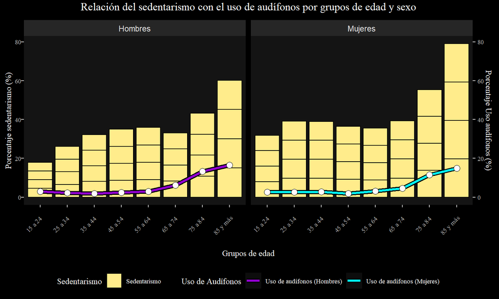

## RESULTADOS (V)

#### *Relación del sedentarismo con el uso de audífonos por grupos de edad y sexo (V)*

##### GRÁFICO II

```r
grafico1 %>%
  ggplot() +
  geom_col(aes(x = Sexo, y = porcentaje_sedentarios/4, fill = "Sedentarismo"), color = "black") +
  scale_fill_manual(values = c("#FFEC8B")) +
  scale_y_continuous(sec.axis = sec_axis(~., name = "Porcentaje Uso audífonos (%)")) +
  guides(x = guide_axis(angle =45)) +
  guides(fill = guide_legend(title = "Sedentarismo")) +
  guides(shape = guide_legend(title = "Uso de Audífonos")) +
  facet_wrap(facets = vars(Edad), nrow = 2) +
  geom_point(data = grafico1, aes(x = Sexo, y = porcentaje_audifonos, shape = "Uso de Audifonos"),
      size=3, fill="snow", color = "black") +
  scale_shape_manual(values = c(21, 21)) +
```

## RESULTADOS (VI)

#### *Relación del sedentarismo con el uso de audífonos por grupos de edad y sexo (VI)*

##### GRÁFICO II

```r
  labs(x= "División por sexos",
       y = "Porcentaje sedentarismo (%)",
       title = "Relación del sedentarismo con el uso de audífonos según sexo y edad") +
  dark_theme_gray() +
    theme(panel.grid.major = element_blank(), panel.grid.minor = element_blank(),
    plot.title =element_text(
        family = "serif",
        size = 12,
        hjust = 0.5,
        vjust = 2),
    axis.title = element_text(
                   family = "serif",
                   size = 9),
    axis.text = element_text(
                   family = "serif",
                   size = 7),
    axis.text.x = element_text(
                    margin=margin(8, b = 12)),
    axis.text.y = element_text(
                    margin=margin(8, b = 12))) +
```

## RESULTADOS (VII)

#### *Relación del sedentarismo con el uso de audífonos por grupos de edad y sexo (VII)*

##### GRÁFICO II

```r
theme(legend.title = element_text(
                      family = "serif",
                      size = 9),
        legend.text = element_text (
                      family = "serif",
                      size = 7),
        legend.position = "bottom")
```

## RESULTADOS (VII)

#### *Relación del sedentarismo con el uso de audífonos por grupos de edad y sexo (VII)*

##### GRÁFICO II

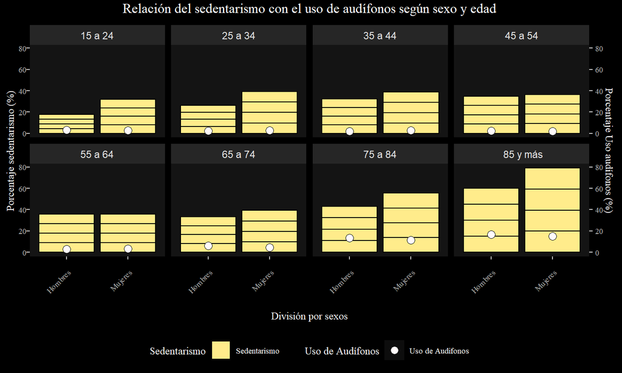

## RESULTADOS (VIII)

#### *Relación del sedentarismo con el uso de gafas por grupos de edad y sexo (I)*

##### GRÁFICO III

```r
grafico2_H <- grafico2 %>% filter(.data = ., Sexo == "Hombres")
grafico2_M <- grafico2 %>% filter(.data = ., Sexo == "Mujeres")

grafico2 %>%
  ggplot() +
  geom_col(aes(x = Edad, y = porcentaje_sedentarios/4, fill = "Sedentarismo"), color = "black") +
  scale_fill_manual(values = c("#FFEC8B")) +
  geom_borderline(data = grafico2_H, aes(x = Edad, y = porcentaje_gafas,
      color = "Uso de gafas (Hombres)"), linewidth = 1.2, bordercolor = "black", group = 1) +
  geom_borderline(data = grafico2_M, aes(x = Edad, y = porcentaje_gafas,
      color = "Uso de gafas (Mujeres)"), linewidth = 1.2, bordercolor = "black",group = 1) +
  scale_y_continuous(sec.axis = sec_axis(~., name = "Porcentaje Uso gafas (%)")) +
  guides(x = guide_axis(angle =45)) +
  guides(fill = guide_legend(title = "Sedentarismo")) +
  guides(color = guide_legend(title = "Uso de Gafas")) +
  facet_wrap(facets = vars(Sexo), nrow = 1) +
  geom_point(data = grafico2_M, aes(x = Edad, y = porcentaje_gafas), size=3, shape=21,
      fill="snow", color = "black") +
  geom_point(data = grafico2_H, aes(x = Edad, y = porcentaje_gafas), size=3, shape=21,
      fill="snow", color = "black") +
```

## RESULTADOS (IX)

#### *Relación del sedentarismo con el uso de gafas por grupos de edad y sexo (II)*

##### GRÁFICO III

```r
labs(x = "Grupos de edad",
       y = "Porcentaje sedentarismo (%)",
       title = "Relación del sedentarismo con el uso de gafas según sexo y edad") +
  dark_theme_gray() +
    theme(panel.grid.major = element_blank(), panel.grid.minor = element_blank(),
    plot.title =element_text(
        family = "serif",
        size = 12,
        hjust = 0.5,
        vjust = 2),
    axis.title = element_text(
                   family = "serif",
                   size = 9),
    axis.text = element_text(
                   family = "serif",
                   size = 7),
    axis.text.x = element_text(
                    margin=margin(8, b = 12)),
    axis.text.y = element_text(
                    margin=margin(8, b = 12))) + scale_color_manual(values = c("#9400D3", "cyan")) +
```

## RESULTADOS (X)

#### *Relación del sedentarismo con el uso de gafas por grupos de edad y sexo (III)*

##### GRÁFICO III

```r
theme(legend.title = element_text(
                      family = "serif",
                      size = 9),
        legend.text = element_text (
                      family = "serif",
                      size = 7),
        legend.position = "bottom")
```

## RESULTADOS (XI)

#### *Relación del sedentarismo con el uso de gafas por grupos de edad y sexo (IV)*

##### GRÁFICO III

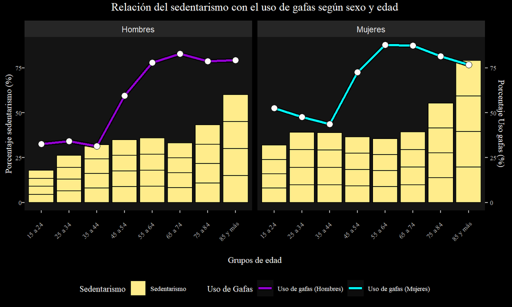

## RESULTADOS (XII)

#### *Relación del sedentarismo con el uso de gafas por grupos de edad y sexo (V)*

##### GRÁFICO IV

```r
grafico2 %>%
  ggplot() +
  geom_col(aes(x = Sexo, y = porcentaje_sedentarios/4, fill = "Sedentarismo"), color = "black") +
  scale_fill_manual(values = c("#FFEC8B")) +
  scale_y_continuous(sec.axis = sec_axis(~., name = "Porcentaje Uso gafas (%)")) +
  guides(x = guide_axis(angle =45)) +
  guides(fill = guide_legend(title = "Sedentarismo")) +
  guides(shape = guide_legend(title = "Uso de Gafas")) +
  facet_wrap(facets = vars(Edad), nrow = 2) +
  geom_point(data = grafico2, aes(x = Sexo, y = porcentaje_gafas, shape = "Uso de Gafas"),
      size=3, fill="snow", color = "black") +
  scale_shape_manual(values = c(21, 21)) +
```

## RESULTADOS (XIII)

#### *Relación del sedentarismo con el uso de gafas por grupos de edad y sexo (VI)*

##### GRÁFICO IV

```r
labs(x= "División por sexos",
       y = "Porcentaje sedentarismo (%)",
       title = "Relación del sedentarismo con el uso de gafas según sexo y edad") +
  dark_theme_gray() +
    theme(panel.grid.major = element_blank(), panel.grid.minor = element_blank(),
    plot.title =element_text(
        family = "serif",
        size = 12,
        hjust = 0.5,
        vjust = 2),
    axis.title = element_text(
                   family = "serif",
                   size = 9),
    axis.text = element_text(
                   family = "serif",
                   size = 7),
    axis.text.x = element_text(
                    margin=margin(8, b = 12)),
    axis.text.y = element_text(
                    margin=margin(8, b = 12))) +
```

## RESULTADOS (XIV)

#### *Relación del sedentarismo con el uso de gafas por grupos de edad y sexo (VII)*

##### GRÁFICO IV

```r
theme(legend.title = element_text(
                      family = "serif",
                      size = 9),
        legend.text = element_text (
                      family = "serif",
                      size = 7),
        legend.position = "bottom")
```

## RESULTADOS (XV)

#### *Relación del sedentarismo con el uso de gafas por grupos de edad y sexo (VIII)*

##### GRÁFICO IV

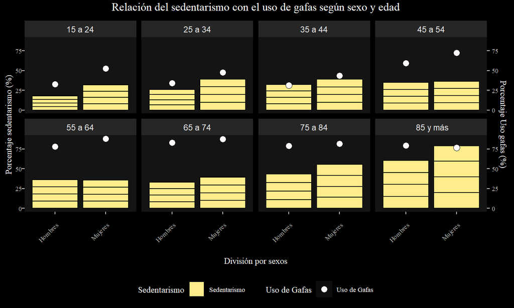

## CONCLUSIONES

En definitiva, las conclusiones **no se pueden considerar sólidas certezas**, pero pensamos que sí que siembran la semilla para **futuros estudios sobre la relación poco estudiada** y, aparentemente, existente, entre uso de gafas y/o audífonos como indicativo directo de enfermedad visuales y/o auditivas; y el estilo de vida sedentario de las poblaciones.

## BIBLIOGRAFÍA 📖

[1] Rodulfo, J. I. A. (2019). Sedentarism, a disease from XXI century. Clínica e Investigación en arteriosclerosis (English edition), 31(5), 233-240. https://doi.org/10.1016/j.artere.2019.04.001

[2] Hu, F. B. (2003). Sedentary lifestyle and risk of obesity and type 2 diabetes. Lipids, 38(2), 103-108.

[3] R Core Team (2023). *R: A Language and Environment for Statistical Computing*. R Foundation for Statistical Computing, Vienna, Austria. https://www.R-project.org/.

[4] Stanley J, Arendt C (2023). *tidyjson: Tidy Complex ‘JSON’*. R package version 0.3.2, https://CRAN.R-project.org/package=tidyjson.

[5] Couture-Beil A (2022). *rjson: JSON for R*. R package version 0.2.21, https://CRAN.R-project.org/package=rjson.

## BIBLIOGRAFÍA (II) 📖

[6] Wickham H, Averick M, Bryan J, Chang W, McGowan LD, François R, Grolemund G, Hayes A, Henry L, Hester J, Kuhn M, Pedersen TL, Miller E, Bache SM, Müller K, Ooms J, Robinson D, Seidel DP, Spinu V, Takahashi K, Vaughan D, Wilke C, Woo K, Yutani H (2019). “Welcome to the tidyverse.” *Journal of Open Source Software*, *4*(43), 1686. doi:10.21105/joss.01686 https://doi.org/10.21105/joss.01686.

[7] Wickham H, Hester J, Bryan J (2023). *readr: Read Rectangular Text Data*. R package version 2.1.4, https://CRAN.R-project.org/package=readr.

[8] Wickham H, Bryan J (2023). *readxl: Read Excel Files*. R package version 1.4.3, https://CRAN.R-project.org/package=readxl.

[9] Wickham H, François R, Henry L, Müller K, Vaughan D (2023). *dplyr: A Grammar of Data Manipulation*. R package version 1.1.3, https://CRAN.R-project.org/package=dplyr.

[10] H. Wickham. ggplot2: Elegant Graphics for Data Analysis. Springer-Verlag New York, 2016.

## BIBLIOGRAFÍA (III) 📖

[11] Wickham H, Vaughan D, Girlich M (2023). *tidyr: Tidy Messy Data*. R package version 1.3.0, https://CRAN.R-project.org/package=tidyr.

[12] Scott J (2022). *ggborderline: Line Plots that Pop*. R package version 0.2.0, https://CRAN.R-project.org/package=ggborderline.

[13] Grantham N (2019). *ggdark: Dark Mode for ‘ggplot2’ Themes*. R package version 0.2.1, https://CRAN.R-project.org/package=ggdark.